# Part II - (Ford GoBike Data set - Explontory part)

### by (Afnan Alabdan)

## Investigation Overview

- The majority of the users are males and between 20 - 40 years old.
- The Cutsomers were having more duration time compared to Subscribers and they tends to spend more time on riding a bike on the weekends.
- A high proportion of the customers and Subscribers uses GoBike rides on the weekdays at 8am and 5pm.

## Dataset Overview

> The Ford GoBike data set includes information about individual rides made in a bike-sharing system covering the greater San Francisco Bay area.This data collected from Feb 2019.

## The Gender and age group that are more likely to use GoBike

As we can see that the most of GoBike riders are males and their age group are between 20 - 40 years old

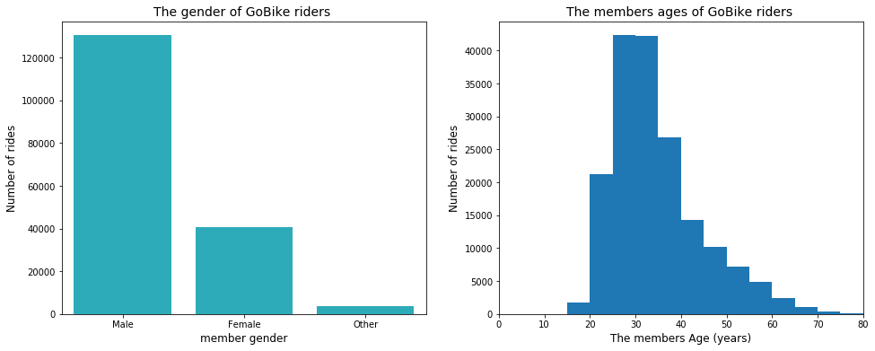

## Duartion in minute for each day of a week to each user type

the chart showed that Saturday and Sunday having the most duration time in minute.The Subscribers were having a less duration time compared to Customers.Which means that Customers are more likely to spends more time in a trip.

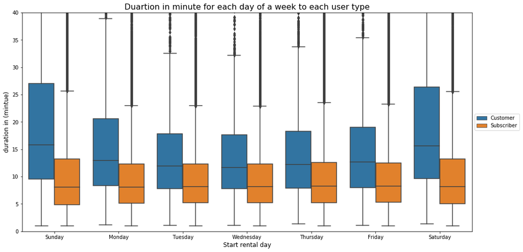

## The Start Rentals hour and day for Customers

the chart show that the Start hour of the weekdays different from weekends days with a high demands in the afternoon and above while in the weekdays the high demands are at 8am and 5pm.

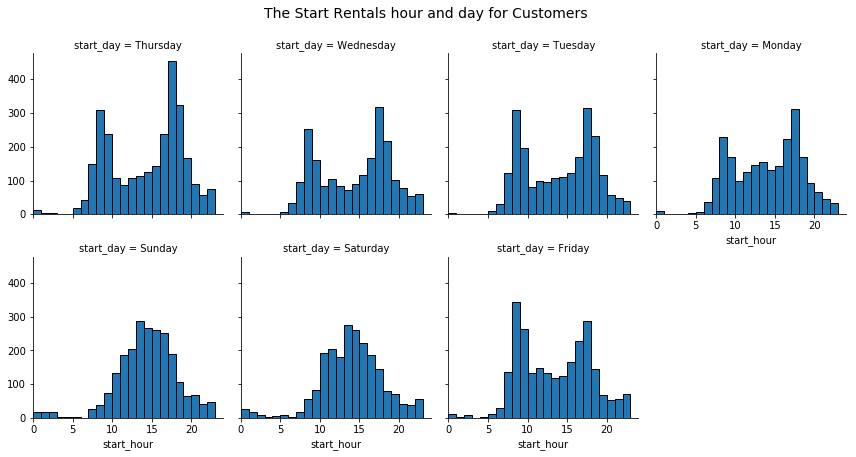

## The Start Rentals hour and day for Subscriber

As we can see from the chart which is very interesting is that the weekend days is the lowest Number of rentals for the Subscribers which could means that the most of the Subscribers used the GoBike system for their work and also with the same pattern in the rental start hour in the weekdays.

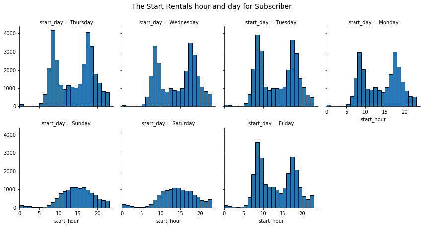